# Tarea 4 - Regresión Simple Bloomberg

Israel Isaías Orta Reyna

2026-10-25

```r
library(readxl)

archivo <- "Tarea3_Bloomberg_Datos.xlsx"

raw <- read_excel(
  archivo,
  sheet = "1 MIN",
  col_names = FALSE
)

datos <- data.frame(
  AAPL  = suppressWarnings(as.numeric(raw[[2]])),
  MSFT  = suppressWarnings(as.numeric(raw[[5]])),
  GOOGL = suppressWarnings(as.numeric(raw[[8]])),
  META  = suppressWarnings(as.numeric(raw[[11]])),
  NVDA  = suppressWarnings(as.numeric(raw[[14]])),
  AMZN  = suppressWarnings(as.numeric(raw[[17]]))
)

datos <- na.omit(datos)

head(datos)
```

```
##       AAPL    MSFT   GOOGL   META    NVDA    AMZN
## 5  334.270 533.670 351.605 723.34 231.075 260.500
## 6  334.215 533.590 351.690 722.98 230.845 260.110
## 7  334.320 533.305 351.930 723.24 230.825 260.080
## 8  334.385 533.203 352.050 723.41 230.740 260.120
## 9  334.460 533.000 352.150 723.22 230.940 260.170
## 10 334.520 532.990 352.035 722.21 230.790 259.955
```

```r
dim(datos)
```

```
## [1] 692   6
```

```r
# Regresiones lineales simples
modelo_msft  <- lm(AAPL ~ MSFT, data = datos)
modelo_googl <- lm(AAPL ~ GOOGL, data = datos)
modelo_meta  <- lm(AAPL ~ META, data = datos)
modelo_nvda  <- lm(AAPL ~ NVDA, data = datos)
modelo_amzn  <- lm(AAPL ~ AMZN, data = datos)

summary(modelo_msft)
```

```
##
## Call:
## lm(formula = AAPL ~ MSFT, data = datos)
##
## Residuals:
##     Min      1Q  Median      3Q     Max
## -2.6383 -0.7669 -0.0247  0.5052  3.9322
##
## Coefficients:
##              Estimate Std. Error t value Pr(>|t|)
## (Intercept) -84.46224    7.64659  -11.05   <2e-16 ***
## MSFT          0.78590    0.01422   55.28   <2e-16 ***
## ---
## Signif. codes:  0 '***' 0.001 '**' 0.01 '*' 0.05 '.' 0.1 ' ' 1
##
## Residual standard error: 1.094 on 690 degrees of freedom
## Multiple R-squared:  0.8158, Adjusted R-squared:  0.8155
## F-statistic:  3056 on 1 and 690 DF,  p-value: < 2.2e-16
```

```r
summary(modelo_googl)
```

```
##
## Call:
## lm(formula = AAPL ~ GOOGL, data = datos)
##
## Residuals:
##     Min      1Q  Median      3Q     Max
## -5.3889 -2.1660  0.8422  1.9550  3.9817
##
## Coefficients:
##             Estimate Std. Error t value Pr(>|t|)
## (Intercept) 94.04104   26.62905   3.532 0.000441 ***
## GOOGL        0.69196    0.07546   9.169  < 2e-16 ***
## ---
## Signif. codes:  0 '***' 0.001 '**' 0.01 '*' 0.05 '.' 0.1 ' ' 1
##
## Residual standard error: 2.405 on 690 degrees of freedom
## Multiple R-squared:  0.1086, Adjusted R-squared:  0.1073
## F-statistic: 84.08 on 1 and 690 DF,  p-value: < 2.2e-16
```

```r
summary(modelo_meta)
```

```
##
## Call:
## lm(formula = AAPL ~ META, data = datos)
##
## Residuals:
##     Min      1Q  Median      3Q     Max
## -2.6379 -1.1247 -0.1203  1.0904  4.5934
##
## Coefficients:
##              Estimate Std. Error t value Pr(>|t|)
## (Intercept) 2.067e+02  3.159e+00   65.44   <2e-16 ***
## META        1.789e-01  4.297e-03   41.62   <2e-16 ***
## ---
## Signif. codes:  0 '***' 0.001 '**' 0.01 '*' 0.05 '.' 0.1 ' ' 1
##
## Residual standard error: 1.36 on 690 degrees of freedom
## Multiple R-squared:  0.7151, Adjusted R-squared:  0.7147
## F-statistic:  1732 on 1 and 690 DF,  p-value: < 2.2e-16
```

```r
summary(modelo_nvda)
```

```
##
## Call:
## lm(formula = AAPL ~ NVDA, data = datos)
##
## Residuals:
##     Min      1Q  Median      3Q     Max
## -2.5441 -0.7787 -0.1933  0.4841  4.9786
##
## Coefficients:
##              Estimate Std. Error t value Pr(>|t|)
## (Intercept) 642.02667    5.69345  112.77   <2e-16 ***
## NVDA         -1.33341    0.02499  -53.36   <2e-16 ***
## ---
## Signif. codes:  0 '***' 0.001 '**' 0.01 '*' 0.05 '.' 0.1 ' ' 1
##
## Residual standard error: 1.125 on 690 degrees of freedom
## Multiple R-squared:  0.805,  Adjusted R-squared:  0.8047
## F-statistic:  2848 on 1 and 690 DF,  p-value: < 2.2e-16
```

```r
summary(modelo_amzn)
```

```
##
## Call:
## lm(formula = AAPL ~ AMZN, data = datos)
##
## Residuals:
##     Min      1Q  Median      3Q     Max
## -4.7175 -2.8909  0.8994  1.8500  4.7119
##
## Coefficients:
##             Estimate Std. Error t value Pr(>|t|)
## (Intercept) 465.5653    29.1765  15.957  < 2e-16 ***
## AMZN         -0.4885     0.1119  -4.365 1.47e-05 ***
## ---
## Signif. codes:  0 '***' 0.001 '**' 0.01 '*' 0.05 '.' 0.1 ' ' 1
##
## Residual standard error: 2.513 on 690 degrees of freedom
## Multiple R-squared:  0.02687,    Adjusted R-squared:  0.02546
## F-statistic: 19.05 on 1 and 690 DF,  p-value: 1.467e-05
```

```r
# Matriz de correlación
cor(datos)
```

```
##             AAPL       MSFT      GOOGL       META       NVDA       AMZN
## AAPL   1.0000000  0.9032068  0.3295729  0.8456542 -0.8971929 -0.1639208
## MSFT   0.9032068  1.0000000  0.4484707  0.9220686 -0.9233909 -0.2140473
## GOOGL  0.3295729  0.4484707  1.0000000  0.4528834 -0.4345952  0.2329492
## META   0.8456542  0.9220686  0.4528834  1.0000000 -0.9451481 -0.3881894
## NVDA  -0.8971929 -0.9233909 -0.4345952 -0.9451481  1.0000000  0.3249197
## AMZN  -0.1639208 -0.2140473  0.2329492 -0.3881894  0.3249197  1.0000000
```

```r
resumen_simples <- data.frame(
  Variable = c("MSFT", "GOOGL", "META", "NVDA", "AMZN"),

  Coeficiente = c(
    coef(modelo_msft)[2],
    coef(modelo_googl)[2],
    coef(modelo_meta)[2],
    coef(modelo_nvda)[2],
    coef(modelo_amzn)[2]
  ),

  R2 = c(
    summary(modelo_msft)$r.squared,
    summary(modelo_googl)$r.squared,
    summary(modelo_meta)$r.squared,
    summary(modelo_nvda)$r.squared,
    summary(modelo_amzn)$r.squared
  ),

  P_value = c(
    summary(modelo_msft)$coefficients[2,4],
    summary(modelo_googl)$coefficients[2,4],
    summary(modelo_meta)$coefficients[2,4],
    summary(modelo_nvda)$coefficients[2,4],
    summary(modelo_amzn)$coefficients[2,4]
  )
)

resumen_simples
```

```
##       Variable Coeficiente         R2       P_value
## MSFT      MSFT   0.7858980 0.81578253 1.162952e-255
## GOOGL    GOOGL   0.6919620 0.10861829  5.387447e-19
## META      META   0.1788496 0.71513095 2.555849e-190
## NVDA      NVDA  -1.3334146 0.80495509 4.224375e-247
## AMZN      AMZN  -0.4884526 0.02687004  1.466676e-05
```

## Interpretación de las regresiones simples

Al revisar las cinco regresiones, todas las variables resultaron estadísticamente significativas, ya que sus p-values son menores a 0.05. Sin embargo, no todas explican de la misma manera los movimientos de AAPL.

MSFT fue la variable con mayor poder explicativo, con un R² de 0.8158 y una relación positiva con AAPL. Esto quiere decir que en esta muestra los movimientos de MSFT y AAPL estuvieron bastante relacionados.

NVDA también presentó un R² alto de 0.8050, aunque en este caso el coeficiente fue negativo. META tuvo un R² de 0.7151 y una relación positiva.

GOOGL mostró una relación positiva, pero con un R² mucho menor de 0.1086. Finalmente, AMZN tuvo el menor poder explicativo, con un R² de 0.0269, aunque su relación también resultó significativa.

En general, los resultados muestran que algunas acciones del mismo sector se mueven de manera mucho más cercana a AAPL que otras. Esto no significa que una acción cause los movimientos de otra, sino que durante el periodo analizado tuvieron una relación estadística más fuerte.

## Preguntas del Capítulo 16 - Gujarati

### 16.1 ¿Cuáles son las características especiales de los datos de corte transversal, series de tiempo y datos de panel?

Los datos de **corte transversal** comparan varias unidades en un mismo momento, por ejemplo diferentes empresas en un mismo año.

Las **series de tiempo** analizan una misma variable a través de varios periodos, por ejemplo el precio de una acción durante varios años.

Los **datos de panel** combinan las dos cosas, porque observan varias unidades y además las siguen a través del tiempo.

### 16.2 ¿Qué se entiende por modelo de efectos fijos (MEF) y cómo considera las dimensiones de tiempo y espacio?

El modelo de efectos fijos permite que cada empresa, persona o unidad tenga características propias que la diferencien de las demás.

La idea es que estas diferencias se reflejan en un intercepto distinto para cada unidad, pero que ese efecto se mantiene constante en el tiempo.

De esta forma el modelo toma en cuenta tanto las diferencias entre las unidades como la información que tenemos de ellas a través de varios periodos.

### 16.3 ¿Qué es el modelo con componentes del error (MCE), en qué difiere del MEF y cuándo utilizar cada uno?

El MCE, también llamado modelo de efectos aleatorios, considera que las diferencias entre las unidades forman parte del error del modelo y se comportan de manera aleatoria.

La diferencia principal es que en efectos fijos cada unidad tiene un efecto propio, mientras que en efectos aleatorios ese efecto se considera parte de una población más grande.

Si las características particulares de cada unidad están relacionadas con las variables que estamos usando, sería más adecuado utilizar efectos fijos. Si no existe esa relación, podría utilizarse efectos aleatorios.

### 16.4 ¿Hay diferencia entre MCVD, estimación dentro de grupos y primeras diferencias?

Sí hay diferencia en la forma en que trabajan, aunque los tres buscan controlar las diferencias particulares que existen entre las unidades.

El MCVD utiliza variables dummy para distinguir a cada unidad. El método dentro de grupos trabaja con las diferencias respecto al promedio de cada unidad y primeras diferencias compara cada observación con la anterior.

Por eso el objetivo es parecido, pero la forma en que se transforman o utilizan los datos cambia.

## Evidencia de Bloomberg

### Regresión lineal simple

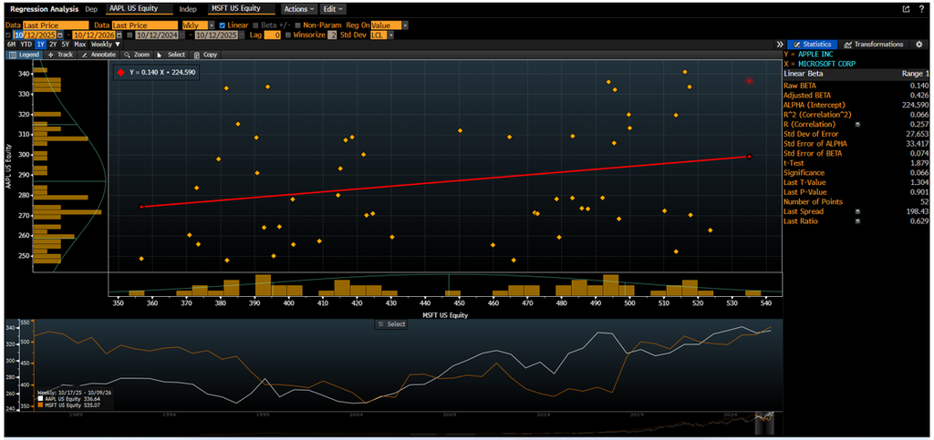

Regresión lineal simple en Bloomberg

La regresión realizada en Bloomberg sirve como referencia para comparar el comportamiento de AAPL frente a MSFT. En RStudio se utilizó información de 1 minuto, mientras que la captura de Bloomberg corresponde a otra frecuencia, por lo que los resultados no son directamente iguales. Aun así, ambas permiten observar la relación entre las dos acciones.

### Matriz de correlación

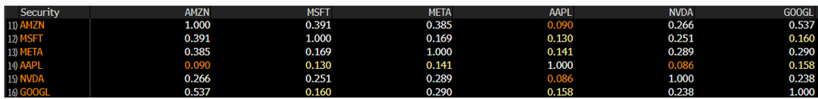

Matriz de correlación en Bloomberg

## Evidencia HowTheMarketWorks

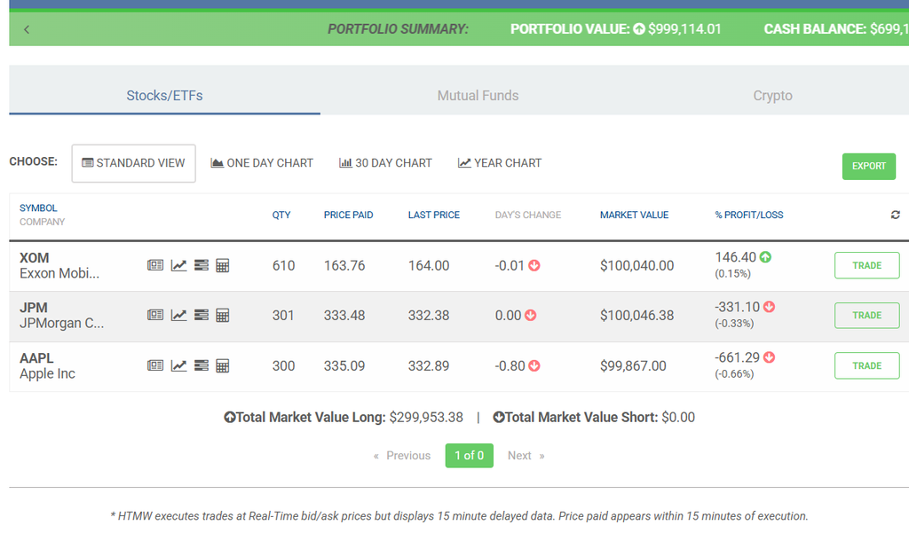

Operaciones en HowTheMarketWorks

En HowTheMarketWorks mantengo posiciones en AAPL, JPM y XOM. Para esta actividad AAPL fue la acción utilizada como variable dependiente en el análisis del sector tecnológico.